# literature

## 1.6 check the quality of the cast

Because of the inaccuracy of cast 5 and 8, we ought to remove them from the ctd list. Begin with cast 8 and the cast 5 i.e remove in descending order so that the numbering of low cast is not afftected.

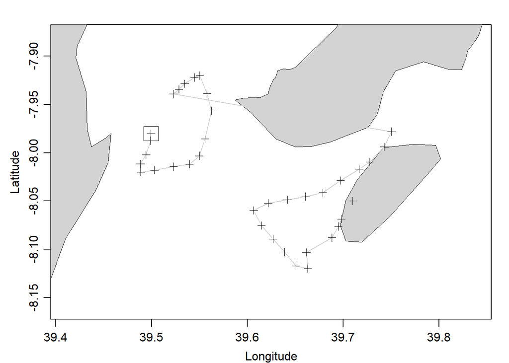

```
Unnamed section has 17 stations:
Index    ID      Lon      Lat  Levels Depth
    1     1   39.499   -7.980      49    12
    2     2   39.499   -7.987      25     6
    3     3   39.494   -8.002      49    12
    4     4   39.488   -8.012      54    13
    5     6   39.489   -8.020      52    13
    6     7   39.503   -8.018      58    14
    7     9   39.523   -8.014      52    13
    8    10   39.540   -8.012      51    12
    9    11   39.550   -8.003      50    12
   10    12   39.556   -7.986      57    14
   11    13   39.563   -7.957      65    16
   12    14   39.558   -7.939      80    20
   13    15   39.550   -7.920      66    16
   14    16   39.545   -7.922      43    10
   15    17   39.535   -7.929      19     4
   16    18   39.528   -7.934       4     1
   17    19   39.523   -7.939       2     0
```

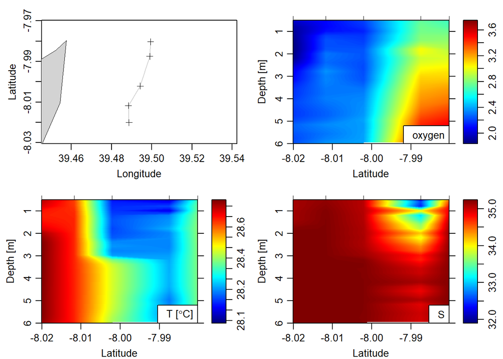

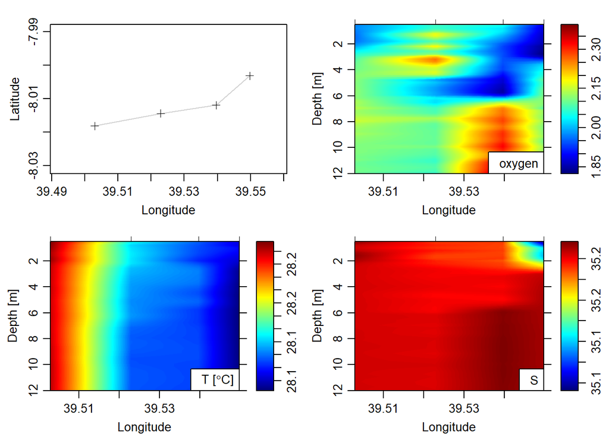

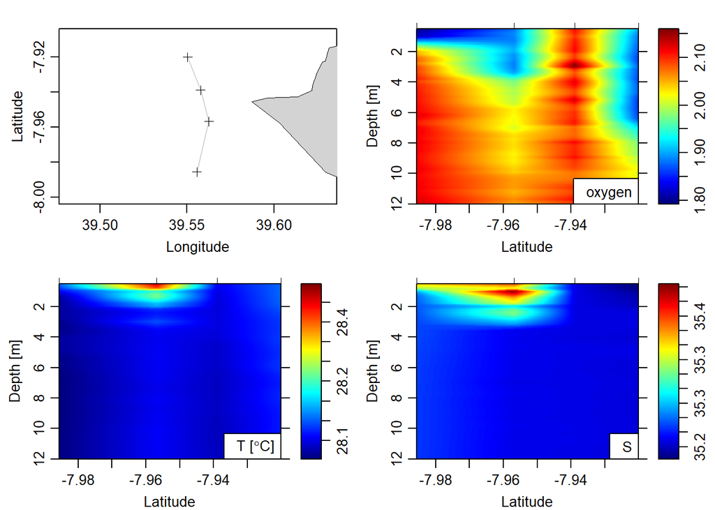

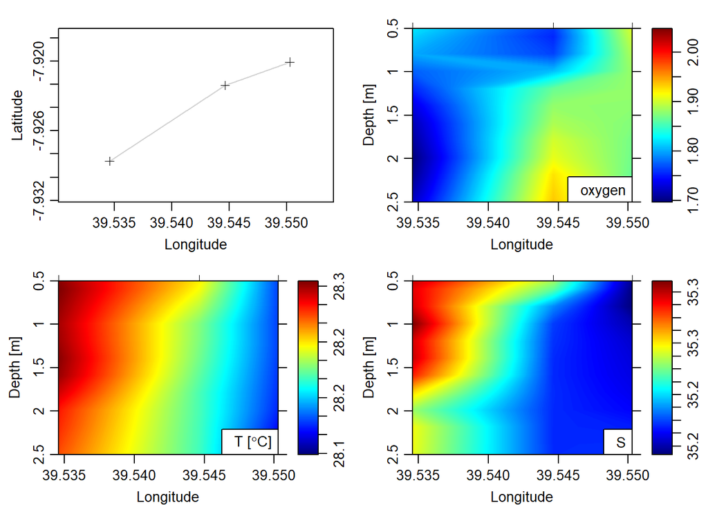

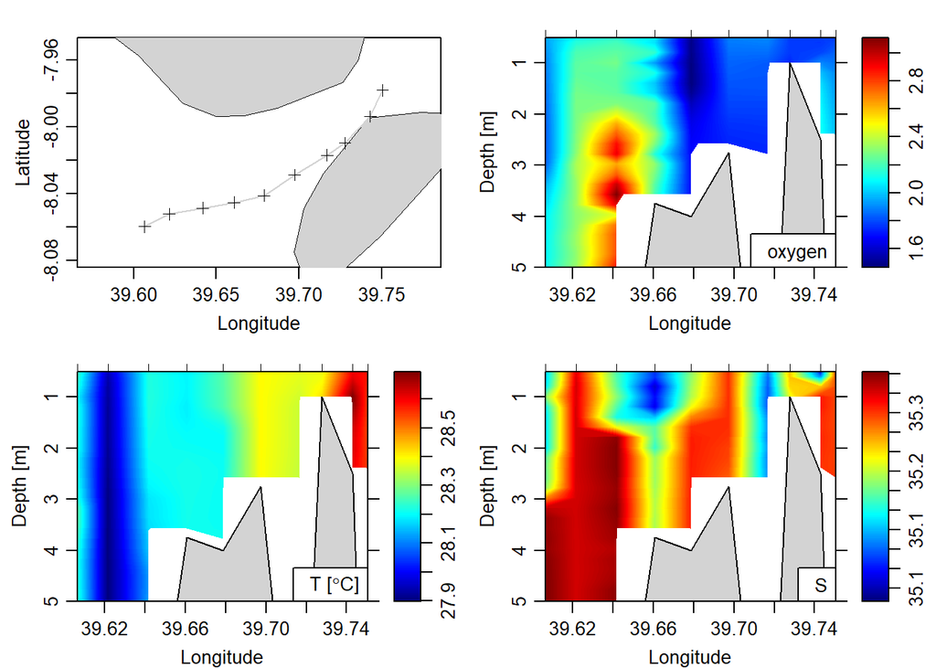

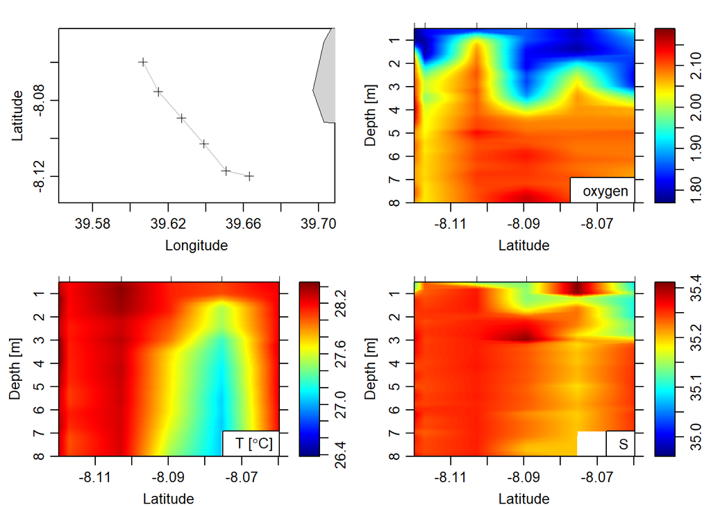

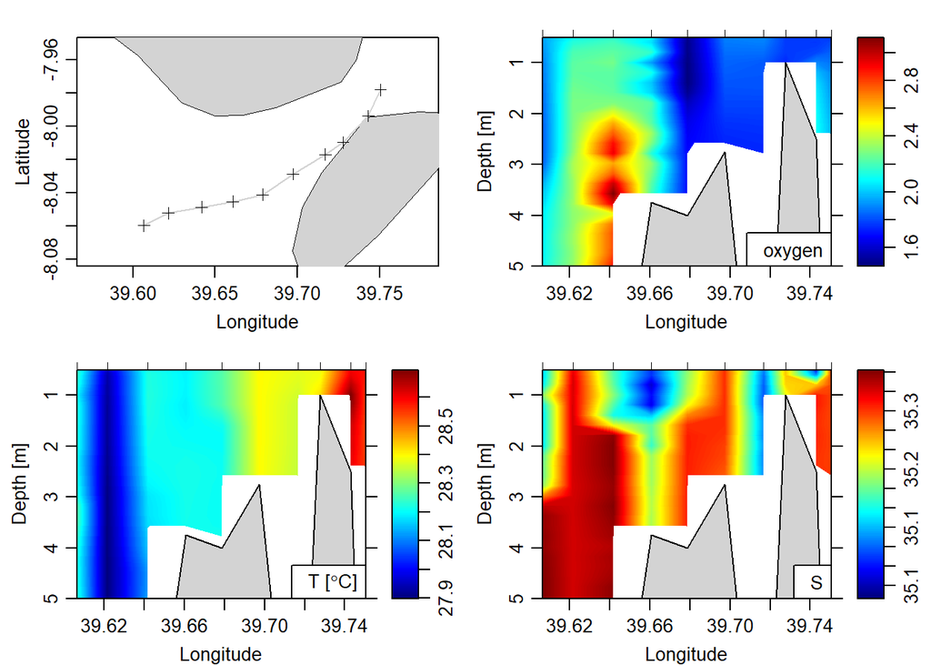

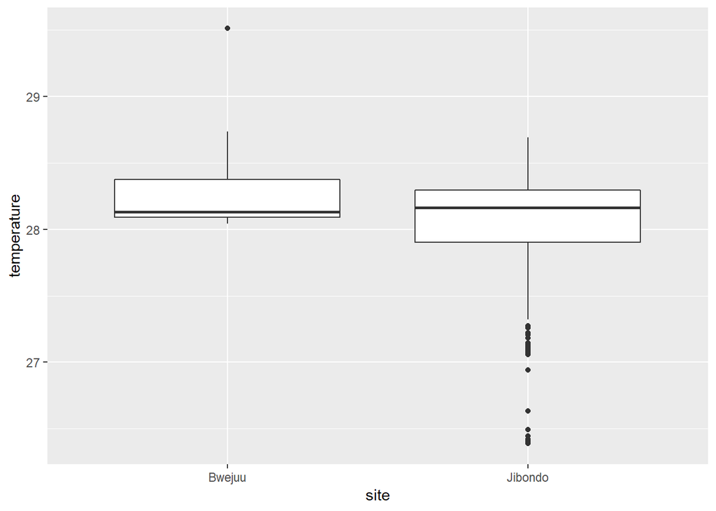

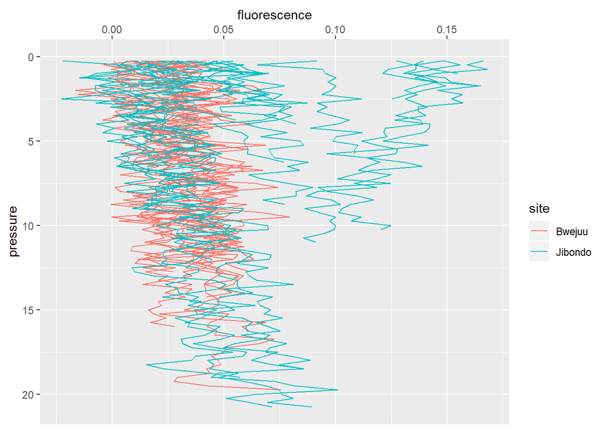

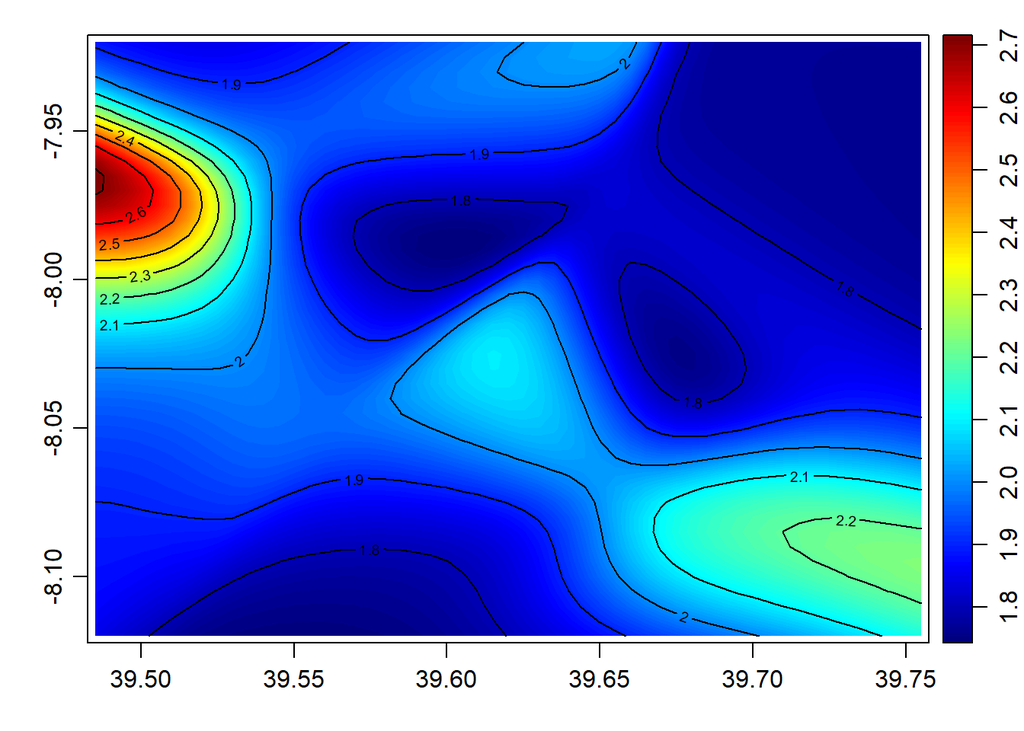

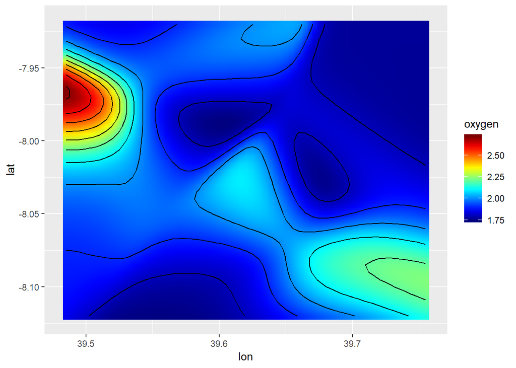

## 1.7 Iterate the process

### 1.7.1 oxygen

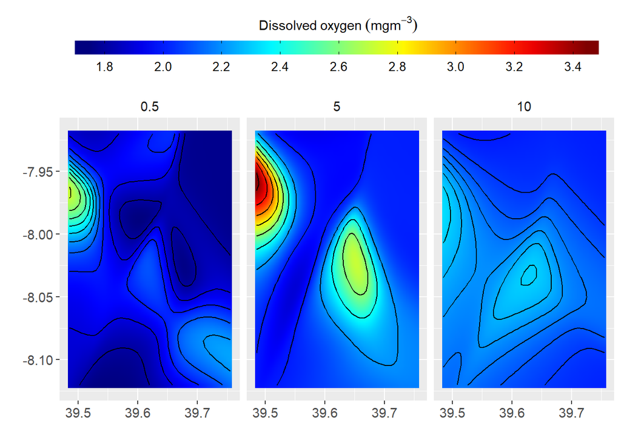

### 1.7.2 temperature

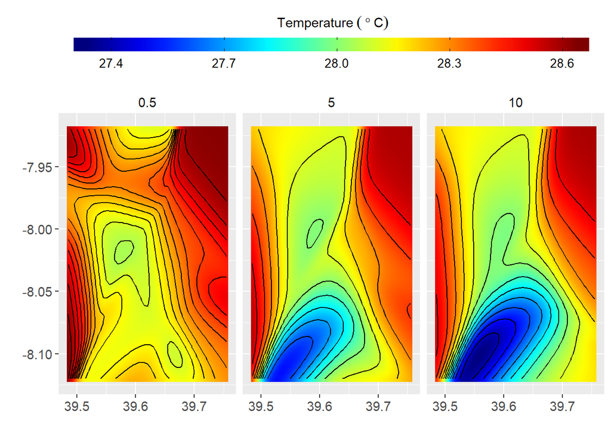

### 1.7.3 salinity

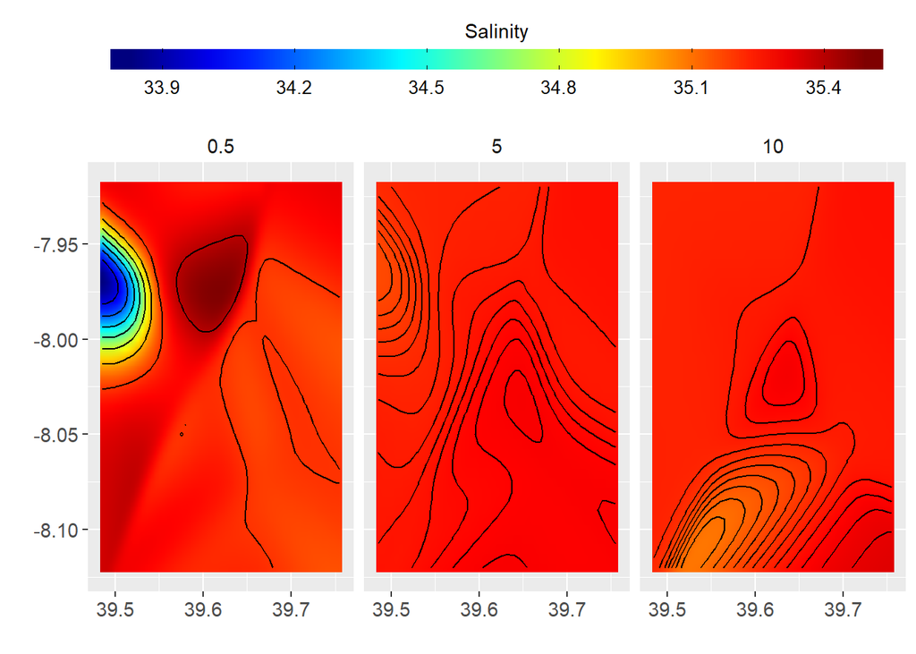

### 1.7.4 fluorescence

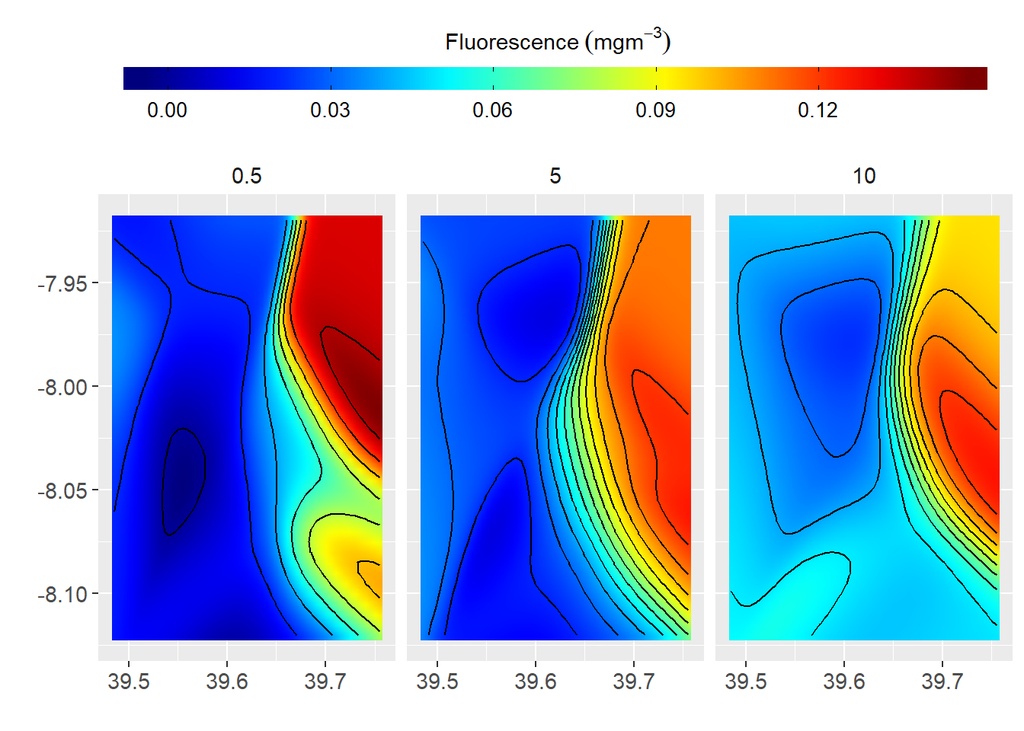

discussion notes coral reefs 1. *reef flats— foot fishery* 2. *inner reefs—diving octopus fishery* 3. *vijamba—diving octopus fishery*

### 1.7.5 landscaping

heterogeity and homogeneity-habitat fragementations

## 1.8 Miamba

make corrections of Kurunge reefs-separate it with the inner reef move name of mto wa fungu to the unmentioned reef merge the previous named mto wa fungu with mchange nyuma separate mchanga nyuma at the interssection of juani and jibondo islands